# The NumPy ndarray: A Multidimensional Array Object

NumPy 是什么？它是大名鼎鼎的，使用 Python 进行科学计算的基础软件包，是 Python 生态系统中数据分析、机器学习、科学计算的主力军，极大简化了向量与矩阵的操作处理。除了计算外，它还包括了：

功能强大的 N 维数组对象。

精密广播功能函数。

集成 C/C+和 Fortran 代码的工具。

强大的线性代数、傅立叶变换和随机数功能

## 1. 创建 nparrays

```python
import numpy as np

arr = np.array([[1,2,3,4],[5,6,7,8]])


#arr=arr.astype(np.int)

#numeric_strings=np.array(['1.25','-9.6','42'],dtype=np.string_)
#numeric_strings.astype(float)
```

```python
print(arr.ndim)#查看数组维度
print(arr.shape)#查看各个维度维数
print(arr.size)#查看元素个数
```

```
2
(2, 4)
8
```

```python
np.zeros((4,5))#注意有2个括号
```

```
array([[0., 0., 0., 0., 0.],
       [0., 0., 0., 0., 0.],
       [0., 0., 0., 0., 0.],
       [0., 0., 0., 0., 0.]])
```

```python
np.empty((2,3,2))#返回 garbage values
```

```
array([[[0., 0.],
        [0., 0.],
        [0., 0.]],

       [[0., 0.],
        [0., 0.],
        [0., 0.]]])
```

```python
np.arange(2,10)
```

```
array([2, 3, 4, 5, 6, 7, 8, 9])
```

## 2. 数学与统计方法

### 2.1 生成随机数

**下面我们先来看numpy的ramdom函数，参考liyangbit: [为什么你用不好numpy的ramdon函数](https://www.cnblogs.com/lemonbit/p/6864179.html)**

python自带的random模块每次只生成一个随机数，相比之下numpy.random快了不止一个数量级，通过下面的例子可以感受到：

```python
from random import normalvariate
N=1000000

%timeit samples = [normalvariate(0, 1) for i in range(N)]
```

```
1.08 s ± 46.2 ms per loop (mean ± std. dev. of 7 runs, 1 loop each)
```

```python
%timeit np.random.normal(size=N)#%timeit 可以查看此代码运行的时间
```

```
39.1 ms ± 950 µs per loop (mean ± std. dev. of 7 runs, 10 loops each)
```

1. np.random.randn(): 生成标准正态分布数据

```python
np.random.randn(2,4)
```

```
array([[ 1.12643478, -2.0021022 ,  1.21496936,  0.91407258],
       [-0.09088736, -0.12312242,  0.97771158,  0.90225037]])
```

```python
np.random.seed(1234) #也可以用seed生成一样的数据
np.random.randn(2,3,2)
```

```
array([[[ 0.47143516, -1.19097569],
        [ 1.43270697, -0.3126519 ],
        [-0.72058873,  0.88716294]],

       [[ 0.85958841, -0.6365235 ],
        [ 0.01569637, -2.24268495],
        [ 1.15003572,  0.99194602]]])
```

1. numpy.random.rand(): 生成[0,1)之间的数据

```python
np.random.rand(4,2)
```

```
array([[0.37025075, 0.56119619],
       [0.50308317, 0.01376845],
       [0.77282662, 0.88264119],
       [0.36488598, 0.61539618]])
```

1. numpy.random.randint(low, high=None, size=None): 返回[low,high）区间随机整数；high没有填写时，默认生成随机数的范围是[0，low)

```python
np.random.randint(-5,5,size=(5,4))
```

```
array([[-4, -2, -4, -2],
       [ 2, -4,  2, -1],
       [-5,  0, -4,  0],
       [ 4,  4, -1, -5],
       [ 4,  3,  3,  1]])
```

1. numpy.random.choice(a, size=None, replace=True, p=None): 从给定的一维数组中生成随机数

```python
np.random.choice(5,3) #从np.arange(5)中选3个数
```

```
array([0, 4, 2])
```

```python
np.random.choice(15,size=(3,2), replace=False)
```

```
array([[13,  0],
       [ 9, 10],
       [ 8, 14]])
```

```python
demo_list = ['lenovo', 'sansumg','moto','xiaomi', 'iphone']
np.random.choice(demo_list,size=(3,3), p=[0.1,0.6,0.1,0.1,0.1])
```

```
array([['iphone', 'iphone', 'moto'],
       ['sansumg', 'sansumg', 'sansumg'],
       ['sansumg', 'sansumg', 'lenovo']], dtype='<U7')
```

### 4.2 算术运算

```python
arr=np.array([[1.,2.,3.],[4.,5.,6.]])
arr
```

```
array([[1., 2., 3.],
       [4., 5., 6.]])
```

```python
arr+arr           #+ - * / ** sqrt exp > maximum modf
```

```
array([[ 2.,  4.,  6.],
       [ 8., 10., 12.]])
```

```python
arr2 = np.array([[0., 4., 1.], [7., 2., 12.]])
arr2
```

```
array([[ 0.,  4.,  1.],
       [ 7.,  2., 12.]])
```

```python
a,b=np.modf(arr2)
b
```

```
array([[ 0.,  4.,  1.],
       [ 7.,  2., 12.]])
```

```python
arr>arr2
```

```
array([[ True, False,  True],
       [False,  True, False]])
```

```python
arr = np.random.randn(7) * 5
a,b=np.modf(arr)#返回小数部分和整数部分
print(arr)
print(a)
print(b)
```

```
[ 1.77010166 -0.17756513  2.82869153  7.72829402 -4.87118167 -0.35172439
  1.53984428]
[ 0.77010166 -0.17756513  0.82869153  0.72829402 -0.87118167 -0.35172439
  0.53984428]
[ 1. -0.  2.  7. -4. -0.  1.]
```

### 4.3 线性代数

```python
x = np.array([[1., 2., 3.], [4., 5., 6.]])
y = np.array([[6., 23.], [-1, 7], [8, 9]])
x
```

```
array([[1., 2., 3.],
       [4., 5., 6.]])
```

```python
y
```

```
array([[ 6., 23.],
       [-1.,  7.],
       [ 8.,  9.]])
```

```python
x.dot(y)  # np.dot(x,y)
```

```
array([[ 28.,  64.],
       [ 67., 181.]])
```

```python
x.T
```

```
array([[1., 4.],
       [2., 5.],
       [3., 6.]])
```

```python
# `numpy.linalg` has a standard set of matrix decompositions and things like inverse and determinant.
# !pip install linalg
from numpy.linalg import inv, qr, solve

X=np.random.randn(5,5)
mat=X.T.dot(X)           #X'X
```

```python
inv(mat)
```

```
array([[ 4.21557829, -5.14252256, -2.8903468 ,  0.14835856,  0.1602116 ],
       [-5.14252256, 15.13454357,  7.77266029,  0.11931843, -0.82879591],
       [-2.8903468 ,  7.77266029,  4.16485207,  0.13155531, -0.32013041],
       [ 0.14835856,  0.11931843,  0.13155531,  0.15963484,  0.13636779],
       [ 0.1602116 , -0.82879591, -0.32013041,  0.13636779,  0.38302807]])
```

```python
mat.dot(inv(mat))
```

```
array([[ 1.00000000e+00,  2.53446936e-17,  8.58546871e-16,
        -1.26489078e-16, -6.14049827e-17],
       [ 8.62283408e-16,  1.00000000e+00,  1.82528044e-15,
         4.51960283e-17,  2.55333583e-17],
       [-3.82020843e-15,  1.09879284e-15,  1.00000000e+00,
        -1.21145473e-16, -2.85781087e-16],
       [ 4.51302635e-15,  2.11695209e-15, -9.00624346e-16,
         1.00000000e+00, -1.63694482e-17],
       [-1.23545282e-15,  3.65512331e-16,  1.64970337e-15,
        -1.20395998e-18,  1.00000000e+00]])
```

```python
q,r=qr(mat)
r
```

```
array([[ -3.08937187,   4.62702489, -12.0020052 ,  19.42828252,
         -6.29403016],
       [  0.        ,  -3.81132062,   6.75331366,   3.84883209,
         -5.17100588],
       [  0.        ,   0.        ,  -0.30514338,   2.09088483,
         -2.50459794],
       [  0.        ,   0.        ,   0.        ,  -3.23209015,
         -0.14253871],
       [  0.        ,   0.        ,   0.        ,   0.        ,
          1.00996676]])
```

```python
#  求解线性方程组

# x1 + x2 + 7*x3 = 2
# 2*x1 + 3*x2 + 5*x3 = 3
# 4*x1 + 2*x2 + 6*x3 = 4

A = np.array([[1, 1, 7], [2, 3, 5], [4, 2, 6]])  # A代表系数矩阵
b = np.array([2, 3, 4])  # b代表常数列
x = solve(A, b)
print(x)
```

```
[0.6  0.35 0.15]
```

| Function | Description |
| --- | --- |
| diag | Return the diagonal (or off-diagonal) elements of a square matrix as a 1D array, or convert a 1D array into a square matrix with zeros on the off-diagonal |
| dot | Matrix multiplication |
| trace | Compute the sum of the diagonal elements |
| det | Compute the matrix determinant |
| eig | Compute the eigenvalues and eigenvectors of a square matrix |
| inv | Compute the inverse of a square matrix |
| pinv | Compute the Moore-Penrose pseudo-inverse of a matrix |
| qr | Compute the QR decomposition |
| svd | Compute the singular value decomposition (SVD) |
| solve | Solve the linear system Ax = b for x, where A is a square matrix |
| lstsq | Compute the least-squares solution to Ax = b |

### 4.4 统计运算

```python
arr = np.random.randn(5, 4)
arr
```

```
array([[ 0.27083585,  1.39198619,  0.07984231, -0.39996458],
       [-1.02785056, -0.58471821,  0.81659393, -0.08194705],
       [-0.34476601,  0.52828815, -1.06898878, -0.51188131],
       [ 0.29120536,  0.5665337 ,  0.50359176,  0.28529568],
       [ 0.48428811,  1.36348151, -0.78110528, -0.46801767]])
```

```python
arr.mean()                   #max min
#np.mean(arr)
```

```
0.06563515465011585
```

```python
arr.sum()
```

```
1.312703093002317
```

- arr.cumsum(); arr.cumprod()

```python
arr = np.array([0, 1, 2, 3, 4, 5, 6, 7])
arr.cumsum() #叠加
```

```
array([ 0,  1,  3,  6, 10, 15, 21, 28], dtype=int32)
```

```python
arr = np.array([[0, 1, 2], [3, 4, 5], [6, 7, 8]])
arr
```

```
array([[0, 1, 2],
       [3, 4, 5],
       [6, 7, 8]])
```

```python
arr.cumsum(axis=0) #行叠加
```

```
array([[ 0,  1,  2],
       [ 3,  5,  7],
       [ 9, 12, 15]], dtype=int32)
```

```python
arr.cumprod(axis=1) #列叠乘
```

```
array([[  0,   0,   0],
       [  3,  12,  60],
       [  6,  42, 336]], dtype=int32)
```

- boolean

```python
# Boolean values are coerced to 1 (True) and 0 (False) in the preceding methods.
arr = np.random.randn(100)
arr > 0
```

```
array([ True, False,  True, False, False,  True, False, False,  True,
       False,  True,  True, False, False, False,  True, False,  True,
       False, False,  True,  True,  True,  True,  True,  True,  True,
       False, False,  True, False,  True,  True, False,  True, False,
        True, False,  True,  True, False,  True,  True,  True, False,
       False,  True, False, False, False, False,  True,  True, False,
       False, False, False,  True,  True,  True,  True,  True, False,
       False, False, False,  True, False,  True,  True, False,  True,
       False, False,  True, False,  True, False, False, False, False,
       False,  True, False, False, False,  True, False, False,  True,
        True, False, False, False,  True, False,  True, False, False,
        True])
```

```python
# Number of positive values
(arr>0).sum()
```

```
46
```

```python
# There are two additional methods, any and all, useful especially for boolean arrays.
bools = np.array([False, False, True, False])
```

```python
bools.any()
```

```
True
```

```python
bools.all()
```

```
False
```

## 3. 引索和切片

### 3.1 整数引索

```python
#二维
arr2d = np.array([[1, 2, 3], [4, 5, 6], [7, 8, 9]])
arr2d
```

```
array([[1, 2, 3],
       [4, 5, 6],
       [7, 8, 9]])
```

```python
arr2d[2]
```

```
array([7, 8, 9])
```

```python
print(arr2d[0][2])
print(arr2d[0, 2])
```

```
3
3
```

```python
#三维
arr3d = np.array([[[1, 2, 3], [4, 5, 6]], [[7, 8, 9], [10, 11, 12]]])
arr3d
```

```
array([[[ 1,  2,  3],
        [ 4,  5,  6]],

       [[ 7,  8,  9],
        [10, 11, 12]]])
```

```python
arr3d[0]
```

```
array([[1, 2, 3],
       [4, 5, 6]])
```

```python
arr3d[1, 0]
```

```
array([7, 8, 9])
```

```python
arr3d[1,0,0]
```

```
7
```

### 3.2 切片

```python
#一维
arr=np.arange(10)
arr
```

```
array([0, 1, 2, 3, 4, 5, 6, 7, 8, 9])
```

```python
arr_slice = arr[5:8]
arr_slice
```

```
array([5, 6, 7])
```

- An important first distinction from Python’s built-in lists is that array slices are views on the original array. This means that the data is not copied, and **any modifications to the view will be reflected in the source array**.

```python
#对切片的改动会反映到原数组上
arr_slice[1] = 12345
arr_slice
arr
```

```
array([    0,     1,     2,     3,     4,     5, 12345,     7,     8,
           9])
```

```python
# 如果需要创建新数组，可以用 .copy()
old_values = arr3d[0].copy()
arr3d[0]=42                       #broadcasting
arr3d
```

```
array([[[42, 42, 42],
        [42, 42, 42]],

       [[ 7,  8,  9],
        [10, 11, 12]]])
```

```python
arr3d[0] = old_values
arr3d
```

```
array([[[ 1,  2,  3],
        [ 4,  5,  6]],

       [[ 7,  8,  9],
        [10, 11, 12]]])
```

当运算中的 2 个数组的形状不同时，numpy 将自动触发广播机制（broadcasting）

```python
#broadcasting
a = np.array([[ 0, 0, 0],
           [10,10,10],
           [20,20,20],
           [30,30,30]])
b = np.array([1,2,3])
print(a + b)
```

```
[[ 1  2  3]
 [11 12 13]
 [21 22 23]
 [31 32 33]]
```

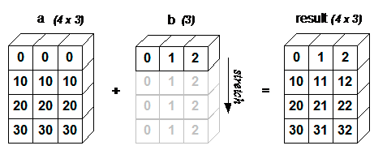

图片来自https://www.runoob.com/numpy/numpy-broadcast.html

```python
#可以应用数据中心化
arr=np.random.randn(4,3)
demeaned=arr-arr.mean(0)
demeaned
```

```
array([[ 1.37357214, -0.03393061, -0.50167379],
       [-1.08360357,  0.22204936,  1.09302921],
       [ 0.92274019,  0.19351016, -0.26557134],
       [-1.21270877, -0.38162891, -0.32578408]])
```

我们继续来看二维数组的切片

```python
#二维
arr2d
```

```
array([[1, 2, 3],
       [4, 5, 6],
       [7, 8, 9]])
```

```python
arr2d[:2]
```

```
array([[1, 2, 3],
       [4, 5, 6]])
```

```python
 arr2d[:2, 1:]
```

```
array([[2, 3],
       [5, 6]])
```

```python
# 整数引索和切片可以一起
arr2d[1, :2]
```

```
array([4, 5])
```

```python
#对于更高维度的切片
arr2d[:, :1]
```

```
array([[1],
       [4],
       [7]])
```

```python
arr2d[:2, 1:] =0       #broadcasting
arr2d
```

```
array([[1, 0, 0],
       [4, 0, 0],
       [7, 8, 9]])
```

### 3.3 逻辑引索

Let’s consider an example where we have some data in an array and an array of names with duplicates.

```python
names = np.array(['Bob', 'Joe', 'Will', 'Bob', 'Will', 'Joe', 'Joe'])
data = np.random.randn(7, 4)
```

```python
names
```

```
array(['Bob', 'Joe', 'Will', 'Bob', 'Will', 'Joe', 'Joe'], dtype='<U4')
```

```python
data
```

```
array([[-0.27664613,  1.92453332,  0.41120402,  0.89076496],
       [ 0.22636323, -2.07861789, -0.38788623, -0.08710697],
       [ 1.12638582,  0.24711172,  0.12117181,  0.29898394],
       [-0.15709914, -0.74046902, -1.24765292,  0.24945522],
       [ 0.58107332,  2.76384408,  0.39932544,  0.66848817],
       [-0.27577373,  0.5004829 ,  0.86306486, -1.05162786],
       [-1.39205408,  1.15392224,  1.18194411,  0.39137145]])
```

```python
names == 'Bob'
```

```
array([ True, False, False,  True, False, False, False])
```

```python
data[names == 'Bob']
```

```
array([[-0.27664613,  1.92453332,  0.41120402,  0.89076496],
       [-0.15709914, -0.74046902, -1.24765292,  0.24945522]])
```

- Boolean selection will not fail if the boolean array is not the correct length.
- To select everything but 'Bob', you can either use `!=` or negate the condition using `~`

```python
names != 'Bob'
```

```
array([False,  True,  True, False,  True,  True,  True])
```

```python
data[~(names == 'Bob')]
```

```
array([[ 0.22636323, -2.07861789, -0.38788623, -0.08710697],
       [ 1.12638582,  0.24711172,  0.12117181,  0.29898394],
       [ 0.58107332,  2.76384408,  0.39932544,  0.66848817],
       [-0.27577373,  0.5004829 ,  0.86306486, -1.05162786],
       [-1.39205408,  1.15392224,  1.18194411,  0.39137145]])
```

- & (and) and | (or)

```python
mask = (names == 'Bob') | (names == 'Will')
mask
```

```
array([ True, False,  True,  True,  True, False, False])
```

```python
data[mask]
```

```
array([[-0.27664613,  1.92453332,  0.41120402,  0.89076496],
       [ 1.12638582,  0.24711172,  0.12117181,  0.29898394],
       [-0.15709914, -0.74046902, -1.24765292,  0.24945522],
       [ 0.58107332,  2.76384408,  0.39932544,  0.66848817]])
```

- The Python keywords `and` and `or` do not work with boolean arrays. Use `&` (and) and `|` (or) instead.

```python
#当然也可以用整个数组的逻辑来引索
data[data < 0] = 0
```

```python
data
```

```
array([[0.        , 1.92453332, 0.41120402, 0.89076496],
       [0.22636323, 0.        , 0.        , 0.        ],
       [1.12638582, 0.24711172, 0.12117181, 0.29898394],
       [0.        , 0.        , 0.        , 0.24945522],
       [0.58107332, 2.76384408, 0.39932544, 0.66848817],
       [0.        , 0.5004829 , 0.86306486, 0.        ],
       [0.        , 1.15392224, 1.18194411, 0.39137145]])
```

```python
data[names != 'Joe'] = 7
```

```python
data
```

```
array([[7.        , 7.        , 7.        , 7.        ],
       [0.22636323, 0.        , 0.        , 0.        ],
       [7.        , 7.        , 7.        , 7.        ],
       [7.        , 7.        , 7.        , 7.        ],
       [7.        , 7.        , 7.        , 7.        ],
       [0.        , 0.5004829 , 0.86306486, 0.        ],
       [0.        , 1.15392224, 1.18194411, 0.39137145]])
```

### 3.4 Fancy Indexing

```python
arr = np.empty((8, 4))
for i in range(8):
    arr[i]=i
```

```python
arr
```

```
array([[0., 0., 0., 0.],
       [1., 1., 1., 1.],
       [2., 2., 2., 2.],
       [3., 3., 3., 3.],
       [4., 4., 4., 4.],
       [5., 5., 5., 5.],
       [6., 6., 6., 6.],
       [7., 7., 7., 7.]])
```

```python
arr[[4, 3, 0, 6]]
```

```
array([[4., 4., 4., 4.],
       [3., 3., 3., 3.],
       [0., 0., 0., 0.],
       [6., 6., 6., 6.]])
```

```python
arr = np.arange(32).reshape((8, 4))
arr
```

```
array([[ 0,  1,  2,  3],
       [ 4,  5,  6,  7],
       [ 8,  9, 10, 11],
       [12, 13, 14, 15],
       [16, 17, 18, 19],
       [20, 21, 22, 23],
       [24, 25, 26, 27],
       [28, 29, 30, 31]])
```

```python
 arr[[1, 5, 7, 2], [0, 3, 1, 2]]
```

```
array([ 4, 23, 29, 10])
```

```python
arr[[1, 5, 7, 2]][:, [0, 3, 1, 2]]
```

```
array([[ 4,  7,  5,  6],
       [20, 23, 21, 22],
       [28, 31, 29, 30],
       [ 8, 11,  9, 10]])
```

- Fancy indexing, unlike slicing, always copies the data into a new array.